# Final_Project_ThienNgo_Le

Student: ThienNgo Nguyen Le

Instructor: Dr. Feng Jiang

Class: Machine Learning - CS3210

Final Project - Applying Machine Learning to Agricultural

# Introduction

Nowadays, Machine learning technique is widely used in many different fields including Agricultural. Many Machine Learning applications are applied to this field such as yield prediction algorithms, automatic harvest system. This technology has a large contribute portion to the improvement of agricultural. However, there are still many challenges and roadblocks on applying machine learning technique in agricultural. The application that is implemented in agricultural has to be a practical application that align with others existing technologies. Machine learning by the word itself tells us that it will requires lots of data, so the gaps in data collection and preparation is also a big challenge. In this project, I focus on data collection strategies and practical implementation of Machine Learning techniques to agriculture. This project has five phrases:

```
1. Data collection strategies.
2. Wild weed detection.
3. Growing stages and environment analysis.
4. Pest and diseases detection.
5. Complete automatic growing model.
```

In this report, I will demonstrate the work I have done for Phrase 1 and Phrase 2.

# 1. Data collection strategies.

As I mentioned in the previous paraghraph, lacking of data is one of the main blocker on appying Machine Learning to Agricultural. So finding advanced tools and method to collect data is important. The first phrase of this project I focus on finding the methods to collect the data. I use Arducam ESP8266 UNO Board conects with "OV2640 Mini Module Camera" to capture the pictures of the plants, "Soil Moisture Sensor" to get the moisture of the soil over time and "Temperature Humidity Sensor" to collect temperature and humidity of the growing environment. All the data will save into a SD card that attached to the board.

[figure not shown]

```python
from IPython.display import Image
PATH = ("/Users/thienngole/Desktop/MSU/10-MSU-Spring-2019/"
        + "CS3120-MachineLearning/Assignment/FinalProject/img/")
Image(filename = PATH + "board.png", width=400, height=400)
```

[figure not shown]

```python
Image(filename = PATH + "sensors.png", width=400, height=400)
```

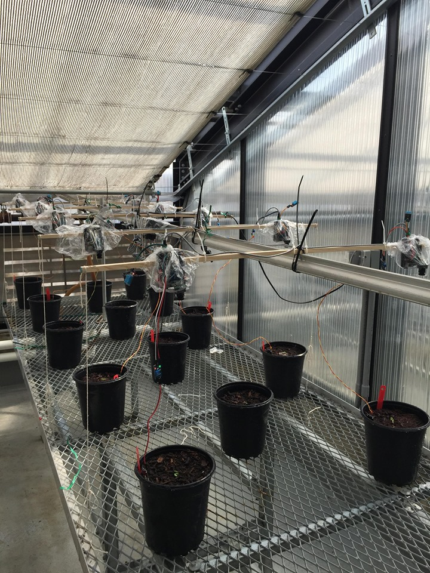

```python
Image(filename = PATH + "greenhouse.jpg", width=300, height=400)
```

This method works really well. However, this method takes some labor work to collect the data from the SD card and store it back to the board. It normally takes me 20 to 30 miniutes to collect the data with 10 samples every week. If we scale it up to 1000 or 10000 samples, it is hard to implement due to the labor work effort. Cloud storage should be an ideal solution that could save us a lot of time in this situation. I came up with a model as show on the figure below. I will usse the Raspberry pi to connect the board with the internet and load the data directly to some cloud storage services, then I can virtually download the data from the cloud storage.

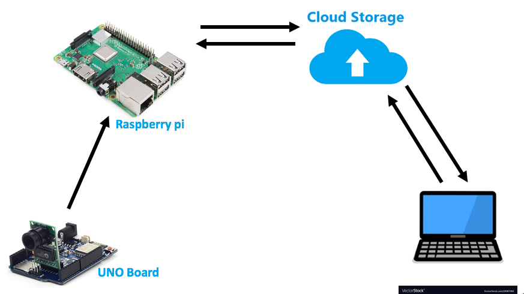

```python
Image(filename = PATH + "rpconnection.png", width=400, height=400)
```